# **Part 1: Network Analysis**

```python
import networkx as nx
import numpy as np
import pandas as pd
import seaborn as sns
import matplotlib.pyplot as plt

sns.set()
```

```python
!pip install pyvis -qq
```

```python
from pyvis import network as net
```

## **1. Creating the networks**

#### 1.1 Edge lists cleaning

```python
!wget https://raw.githubusercontent.com/SDS-AAU/SDS-master/master/00_data/network_krackhard/Krack-High-Tec-Attributes.csv
!wget https://raw.githubusercontent.com/SDS-AAU/SDS-master/master/00_data/network_krackhard/Krack-High-Tec-edgelist-Advice.txt
!wget https://raw.githubusercontent.com/SDS-AAU/SDS-master/master/00_data/network_krackhard/Krack-High-Tec-edgelist-Friendship.txt
!wget https://raw.githubusercontent.com/SDS-AAU/SDS-master/master/00_data/network_krackhard/Krack-High-Tec-edgelist-ReportsTo.txt
```

```python
attributes = pd.read_csv('Krack-High-Tec-Attributes.csv') #this is the node list in the M2.1 exercise basically
advice = pd.read_csv('Krack-High-Tec-edgelist-Advice.txt', delimiter="\s+", header=None, names=['ID_ego','ID_alter','is_edge'])
friendship = pd.read_csv('Krack-High-Tec-edgelist-Friendship.txt', delimiter="\s+", header=None, names=['ID_ego','ID_alter','is_edge'])
reports = pd.read_csv('Krack-High-Tec-edgelist-ReportsTo.txt',delimiter="\s+", header=None, names=['ID_ego','ID_alter','is_edge'])
```

Now that I imported all the relevant files, I will give a quick look to their structure. From the assignment description I know that the connection between nodes is given by the third column of the edges dataframes, which contains a list of 0 and 1. I'll give a quick look at such dataframes and then filter out the zeros before creating the network. In this way, I keep only the edges that create a direct connection.

```python
advice.head()
```

|  | ID_ego | ID_alter | is_edge |
| --- | --- | --- | --- |
| 0 | 1 | 1 | 0 |
| 1 | 1 | 2 | 1 |
| 2 | 1 | 3 | 0 |
| 3 | 1 | 4 | 1 |
| 4 | 1 | 5 | 0 |

I now filter out the 0 in the 'is_edge' column in order to keep only the edges that are actually connected to others. After this I'll create the networks and create a quick (and ugly) plot just to verifiy is there are some major mistakes

```python
advice = advice[advice.is_edge != 0]
```

```python
advice.head(10)
```

|  | ID_ego | ID_alter | is_edge |
| --- | --- | --- | --- |
| 1 | 1 | 2 | 1 |
| 3 | 1 | 4 | 1 |
| 7 | 1 | 8 | 1 |
| 15 | 1 | 16 | 1 |
| 17 | 1 | 18 | 1 |
| 20 | 1 | 21 | 1 |
| 26 | 2 | 6 | 1 |
| 27 | 2 | 7 | 1 |
| 41 | 2 | 21 | 1 |
| 42 | 3 | 1 | 1 |

```python
G_advice = nx.from_pandas_edgelist(advice, source='ID_ego', target='ID_alter', edge_attr='is_edge', create_using=nx.DiGraph)
```

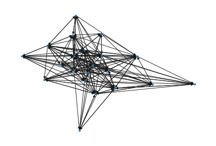

```python
nx.draw(G_advice, with_labels = False, node_size=10)
```

I now repeat the same operation for the friendship and report to edge lists

```python
friendship = friendship[friendship.is_edge != 0]
```

```python
G_friendship = nx.from_pandas_edgelist(friendship, source='ID_ego', target='ID_alter', edge_attr='is_edge', create_using=nx.DiGraph)
```

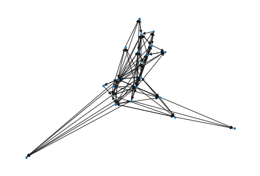

```python
nx.draw(G_friendship, with_labels = False, node_size=10)
```

```python
reports = reports[reports.is_edge != 0]
```

```python
G_reports = nx.from_pandas_edgelist(reports, source='ID_ego', target='ID_alter', edge_attr='is_edge', create_using=nx.DiGraph)
```

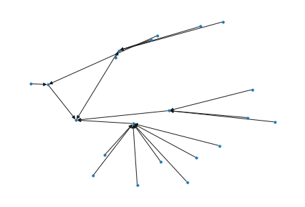

```python
nx.draw(G_reports, with_labels = False, node_size=10)
```

#### 1.2 Setting the attributes

I now work on the attributes. First of all I replace the index automatically generated by pandas with the 'ID' so that I can map the results with the edge lists.

```python
attributes.set_index('ID',inplace=True)
```

Then, in order to apply the nodes attributes to the edges, I create dictionary from the attributes df. I use a transpose matrix while creating the dictionary so that the df is inverted and in the dicitonary each ID is associated with all its info (age, tenure, level and dept).

```python
attributes_dict = attributes.T.to_dict()
```

```python
attributes_dict
```

```
{1: {'AGE': 33.0, 'DEPT': 4.0, 'LEVEL': 3.0, 'TENURE': 9.333},
 2: {'AGE': 42.0, 'DEPT': 4.0, 'LEVEL': 2.0, 'TENURE': 19.583},
 3: {'AGE': 40.0, 'DEPT': 2.0, 'LEVEL': 3.0, 'TENURE': 12.75},
 4: {'AGE': 33.0, 'DEPT': 4.0, 'LEVEL': 3.0, 'TENURE': 7.5},
 5: {'AGE': 32.0, 'DEPT': 2.0, 'LEVEL': 3.0, 'TENURE': 3.333},
 6: {'AGE': 59.0, 'DEPT': 1.0, 'LEVEL': 3.0, 'TENURE': 28.0},
 7: {'AGE': 55.0, 'DEPT': 0.0, 'LEVEL': 1.0, 'TENURE': 30.0},
 8: {'AGE': 34.0, 'DEPT': 1.0, 'LEVEL': 3.0, 'TENURE': 11.333},
 9: {'AGE': 62.0, 'DEPT': 2.0, 'LEVEL': 3.0, 'TENURE': 5.417000000000001},
 10: {'AGE': 37.0, 'DEPT': 3.0, 'LEVEL': 3.0, 'TENURE': 9.25},
 11: {'AGE': 46.0, 'DEPT': 3.0, 'LEVEL': 3.0, 'TENURE': 27.0},
 12: {'AGE': 34.0, 'DEPT': 1.0, 'LEVEL': 3.0, 'TENURE': 8.917},
 13: {'AGE': 48.0, 'DEPT': 2.0, 'LEVEL': 3.0, 'TENURE': 0.25},
 14: {'AGE': 43.0, 'DEPT': 2.0, 'LEVEL': 2.0, 'TENURE': 10.417},
 15: {'AGE': 40.0, 'DEPT': 2.0, 'LEVEL': 3.0, 'TENURE': 8.417},
 16: {'AGE': 27.0, 'DEPT': 4.0, 'LEVEL': 3.0, 'TENURE': 4.667},
 17: {'AGE': 30.0, 'DEPT': 1.0, 'LEVEL': 3.0, 'TENURE': 12.417},
 18: {'AGE': 33.0, 'DEPT': 3.0, 'LEVEL': 2.0, 'TENURE': 9.083},
 19: {'AGE': 32.0, 'DEPT': 2.0, 'LEVEL': 3.0, 'TENURE': 4.833},
 20: {'AGE': 38.0, 'DEPT': 2.0, 'LEVEL': 3.0, 'TENURE': 11.667},
 21: {'AGE': 36.0, 'DEPT': 1.0, 'LEVEL': 2.0, 'TENURE': 12.5}}
```

Now I can attrite the attributes dictionary to the networks so that each node will contain them. I also quickly check that everything is fine by printing them out

```python
nx.set_node_attributes(G_advice, attributes_dict)
nx.set_node_attributes(G_friendship, attributes_dict)
nx.set_node_attributes(G_reports, attributes_dict)
```

```python
G_advice.nodes(data=True)
```

```
NodeDataView({1: {'AGE': 33.0, 'TENURE': 9.333, 'LEVEL': 3.0, 'DEPT': 4.0}, 2: {'AGE': 42.0, 'TENURE': 19.583, 'LEVEL': 2.0, 'DEPT': 4.0}, 4: {'AGE': 33.0, 'TENURE': 7.5, 'LEVEL': 3.0, 'DEPT': 4.0}, 8: {'AGE': 34.0, 'TENURE': 11.333, 'LEVEL': 3.0, 'DEPT': 1.0}, 16: {'AGE': 27.0, 'TENURE': 4.667, 'LE…
```

```python
G_friendship.nodes(data=True)
```

```
NodeDataView({1: {'AGE': 33.0, 'TENURE': 9.333, 'LEVEL': 3.0, 'DEPT': 4.0}, 2: {'AGE': 42.0, 'TENURE': 19.583, 'LEVEL': 2.0, 'DEPT': 4.0}, 4: {'AGE': 33.0, 'TENURE': 7.5, 'LEVEL': 3.0, 'DEPT': 4.0}, 8: {'AGE': 34.0, 'TENURE': 11.333, 'LEVEL': 3.0, 'DEPT': 1.0}, 12: {'AGE': 34.0, 'TENURE': 8.917, 'LE…
```

```python
G_reports.nodes(data=True)
```

```
NodeDataView({1: {'AGE': 33.0, 'TENURE': 9.333, 'LEVEL': 3.0, 'DEPT': 4.0}, 2: {'AGE': 42.0, 'TENURE': 19.583, 'LEVEL': 2.0, 'DEPT': 4.0}, 7: {'AGE': 55.0, 'TENURE': 30.0, 'LEVEL': 1.0, 'DEPT': 0.0}, 3: {'AGE': 40.0, 'TENURE': 12.75, 'LEVEL': 3.0, 'DEPT': 2.0}, 14: {'AGE': 43.0, 'TENURE': 10.417, 'L…
```

## **2. Analysis**

#### 2.A Network level characteristics. Find the overal network level of:

- Density
- Transistivity (Clustering Coefficient)
- Reciprocity

**Density**

The density of a measure represents the share of all connected to all possible connections in the network. If density is 1 means all connections, while 0 means no connections

```python
nx.density(G_advice)
```

```
0.4523809523809524
```

```python
nx.density(G_friendship)
```

```
0.24285714285714285
```

```python
nx.density(G_reports)
```

```
0.047619047619047616
```

**Transitivity**

Transistivity, also called the Clustering Cefficient indicates how much the network tends to be locally clustered.

```python
nx.transitivity(G_advice)
```

```
0.4651600753295669
```

```python
nx.transitivity(G_friendship)
```

```
0.27581863979848864
```

```python
nx.transitivity(G_reports)
```

```
0
```

**Reciprocity**

```python
nx.reciprocity(G_advice)
```

```
0.47368421052631576
```

```python
nx.reciprocity(G_friendship)
```

```
0.45098039215686275
```

```python
nx.reciprocity(G_reports)
```

```
0.0
```

**Are relationships like friendship and advice giving usually reciprocal?**

By looking at the reciprocity rates it's possible to notice how for both advice giving and friendship, more than half of the times the relantinship is not considered reciprocal. The rates in friendship (45%) is lower that the one in advice_giving (47%), which means that managers are more likely to have a reciprocal relationship in advice giving/seeking rather to be friends. But this figure is still less that the half.

**Are friends of your friends also your friends?**

That is measured by the share of closed triplets. The result for friendhsip implies that there is a 27% chance that a friend of a friend is also your friend. So the chance that friends of friends are also someone's friends are close to 1/4

**Are the employees generally more likely to be in a friendship or advice-seeking relationship?** emplyees are more likely to be in an advice-seeking relationship (density at 45%) rather than in a friendship (density at 24,2%). So it seems like that at this company people are more interested in climb the business ladder rather than get to know thei co-workers

#### **2.B Node level characteristics**

Centrality

Centralities can be easily created on node level various centrality algorithms. Since this network is directed we have to split the centrality between in centrality (to which specific person people generally go) and out centrality (to which people a specific person generally goes). Since we have to find out who is the most popular in the network (meaning the person to whom peple go to) I'll consider the inner_degree of centrality.

```python
centrality_dgr_advice = nx.in_degree_centrality(G_advice)
centrality_dgr_friendship = nx.in_degree_centrality(G_friendship)
centrality_dgr_reports = nx.in_degree_centrality(G_reports)
```

```python
centrality_dgr_advice
```

```
{1: 0.65,
 2: 0.9,
 3: 0.25,
 4: 0.4,
 5: 0.25,
 6: 0.5,
 7: 0.65,
 8: 0.5,
 9: 0.2,
 10: 0.45,
 11: 0.55,
 12: 0.35000000000000003,
 13: 0.2,
 14: 0.5,
 15: 0.2,
 16: 0.4,
 17: 0.45,
 18: 0.75,
 19: 0.2,
 20: 0.4,
 21: 0.75}
```

```python
cent_friendship_df = pd.DataFrame({'ID': centrality_dgr_friendship.keys(),
                   'centr_dg': centrality_dgr_friendship.values()})
```

```python
cent_friendship_df["Relation"] = "friendship"
```

```python
cent_advice_df = pd.DataFrame({'ID': centrality_dgr_advice.keys(),
                   'centr_dg': centrality_dgr_advice.values()})
```

```python
cent_advice_df["Relation"] = "advice"
```

```python
cent_report_df = pd.DataFrame({'ID': centrality_dgr_reports.keys(),
                   'centr_dg': centrality_dgr_reports.values()})
```

```python
cent_report_df["Relation"] = "report_to"
```

**Who is most popular in the networks. Who is the most wanted friend, and advice giver?**

After creating the datafram I now merge them with the Attributes one to find who is the most wanted friend and the most wanted advice giver

```python
centrality_friendship_df = pd.merge(cent_friendship_df, attributes, on = "ID", how="left")
```

```python
centrality_friendship_df.sort_values("centr_dg", ascending=False)
```

|  | ID | centr_dg | Relation | AGE | TENURE | LEVEL | DEPT |
| --- | --- | --- | --- | --- | --- | --- | --- |
| 1 | 2 | 0.50 | friendship | 42 | 19.583 | 2 | 4 |
| 0 | 1 | 0.40 | friendship | 33 | 9.333 | 3 | 4 |
| 4 | 12 | 0.40 | friendship | 34 | 8.917 | 3 | 1 |
| 14 | 11 | 0.30 | friendship | 46 | 27.000 | 3 | 3 |
| 13 | 9 | 0.30 | friendship | 62 | 5.417 | 3 | 2 |
| 12 | 5 | 0.30 | friendship | 32 | 3.333 | 3 | 2 |
| 11 | 17 | 0.30 | friendship | 30 | 12.417 | 3 | 1 |
| 9 | 14 | 0.25 | friendship | 43 | 10.417 | 2 | 2 |
| 10 | 19 | 0.25 | friendship | 32 | 4.833 | 3 | 2 |
| 8 | 3 | 0.25 | friendship | 40 | 12.750 | 3 | 2 |
| 7 | 21 | 0.25 | friendship | 36 | 12.500 | 2 | 1 |
| 3 | 8 | 0.25 | friendship | 34 | 11.333 | 3 | 1 |
| 2 | 4 | 0.25 | friendship | 33 | 7.500 | 3 | 4 |
| 6 | 18 | 0.20 | friendship | 33 | 9.083 | 2 | 3 |
| 5 | 16 | 0.20 | friendship | 27 | 4.667 | 3 | 4 |
| 20 | 15 | 0.20 | friendship | 40 | 8.417 | 3 | 2 |
| 16 | 7 | 0.15 | friendship | 55 | 30.000 | 1 | 0 |
| 18 | 20 | 0.15 | friendship | 38 | 11.667 | 3 | 2 |
| 15 | 6 | 0.10 | friendship | 59 | 28.000 | 3 | 1 |
| 17 | 10 | 0.05 | friendship | 37 | 9.250 | 3 | 3 |
| 19 | 13 | 0.05 | friendship | 48 | 0.250 | 3 | 2 |

```python
centrality_advice_df = pd.merge(cent_advice_df, attributes, on = "ID", how="left")
```

```python
centrality_advice_df.sort_values("centr_dg", ascending=False)
```

|  | ID | centr_dg | Relation | AGE | TENURE | LEVEL | DEPT |
| --- | --- | --- | --- | --- | --- | --- | --- |
| 1 | 2 | 0.90 | advice | 42 | 19.583 | 2 | 4 |
| 5 | 18 | 0.75 | advice | 33 | 9.083 | 2 | 3 |
| 6 | 21 | 0.75 | advice | 36 | 12.500 | 2 | 1 |
| 0 | 1 | 0.65 | advice | 33 | 9.333 | 3 | 4 |
| 8 | 7 | 0.65 | advice | 55 | 30.000 | 1 | 0 |
| 12 | 11 | 0.55 | advice | 46 | 27.000 | 3 | 3 |
| 3 | 8 | 0.50 | advice | 34 | 11.333 | 3 | 1 |
| 7 | 6 | 0.50 | advice | 59 | 28.000 | 3 | 1 |
| 14 | 14 | 0.50 | advice | 43 | 10.417 | 2 | 2 |
| 15 | 17 | 0.45 | advice | 30 | 12.417 | 3 | 1 |
| 11 | 10 | 0.45 | advice | 37 | 9.250 | 3 | 3 |
| 2 | 4 | 0.40 | advice | 33 | 7.500 | 3 | 4 |
| 4 | 16 | 0.40 | advice | 27 | 4.667 | 3 | 4 |
| 16 | 20 | 0.40 | advice | 38 | 11.667 | 3 | 2 |
| 13 | 12 | 0.35 | advice | 34 | 8.917 | 3 | 1 |
| 9 | 3 | 0.25 | advice | 40 | 12.750 | 3 | 2 |
| 17 | 5 | 0.25 | advice | 32 | 3.333 | 3 | 2 |
| 19 | 19 | 0.20 | advice | 32 | 4.833 | 3 | 2 |
| 10 | 9 | 0.20 | advice | 62 | 5.417 | 3 | 2 |
| 18 | 13 | 0.20 | advice | 48 | 0.250 | 3 | 2 |
| 20 | 15 | 0.20 | advice | 40 | 8.417 | 3 | 2 |

From the sorted dataframes it's possible to see how the person with ID 2 is the most popular in the network since it has the higest centrality for both advice and friendship. This data makes sense since he covers a vice president position

**Are managers in higher hirarchy more popular as friend, and advice giver?**

A reminder. LEVEL: The level in the corporate hierarchy (coded 1,2 and 3; 1 = CEO, 2 = Vice President, 3 = manager)

```python
centrality_advice_df.groupby(["Relation", "LEVEL"])["centr_dg"].mean()
```

```
Relation  LEVEL
advice    1        0.650000
          2        0.725000
          3        0.371875
Name: centr_dg, dtype: float64
```

```python
centrality_friendship_df.groupby(["Relation", "LEVEL"])["centr_dg"].mean()
```

```
Relation    LEVEL
friendship  1        0.150000
            2        0.300000
            3        0.234375
Name: centr_dg, dtype: float64
```

### 2C: Relational Characteristics: Answer the following questions:

**Are managers from the same 1. department, or on the same 2. hirarchy, 3. age, or 4. tenuere more likely to become friends or give advice?**

To answer this question I'll take into account assortiativity. In a nutshell, it measures if two nodes that share certain characteristics ahve a higher or lower probability to be connected.

So I will run this analysis on the 4 categories and see if this creates more possiblities for them to be connected

I will start my analysis with **friendship**

```python
nx.attribute_assortativity_coefficient(G_friendship, 'DEPT')
```

```
0.15908798145047023
```

```python
nx.attribute_assortativity_coefficient(G_friendship, 'LEVEL')
```

```
0.18750000000000006
```

```python
nx.attribute_assortativity_coefficient(G_friendship, 'AGE')
```

```
-0.031914893617021274
```

```python
nx.attribute_assortativity_coefficient(G_friendship, 'TENURE')
```

```
-0.05271678640089042
```

From the results above we can see that:

- People from the same department are more likely to be friend with people from the same department rather others
- People at the same level tend to be friend with their peers
- Age seems to have a negative influence on the possibility to be friends, meaning that people at the same age are less likely to befriended, which is an interesting and unexpected finding
- Also the amount of years spend within the company seems to have a negative influence on the possibility to be friends, so people that just joined the company are less likely to be friends with their peers

I now proceed with **advice giving**

```python
nx.attribute_assortativity_coefficient(G_advice, 'DEPT')
```

```
0.02390296111309304
```

```python
nx.attribute_assortativity_coefficient(G_advice, 'LEVEL')
```

```
0.008073817762398955
```

```python
nx.attribute_assortativity_coefficient(G_advice, 'AGE')
```

```
-0.03149370125974804
```

```python
nx.attribute_assortativity_coefficient(G_advice, 'TENURE')
```

```
-0.045709982040437976
```

From the results above we can see that when it comes to advice:

- People ask slightly more frequently for advice to people in the same department
- The level doesn't seem to count too much, so manaagers are more likely to ask fro advice to both higher and lower ranks
- People of the same age are less likely to ask advice to their peers
- And also people that spend a similat amount of years in the company are slightly less likely to ask advice to each other

**Are friends more likely to give each others advice?**

To answer this question we need the total number of friends (which I have already since it is the first df when is_edge = 1) and the number of the people that ask advice to their friends, which I need to find.

Then I will calculate a new df starting from the friendship edge list where I will find the not friends, and repeat the same procedure.

```python
friendship.head(2)
```

|  | ID_ego | ID_alter | is_edge |
| --- | --- | --- | --- |
| 1 | 1 | 2 | 1 |
| 3 | 1 | 4 | 1 |

```python
G_friendship.edges
```

```
OutEdgeView([(1, 2), (1, 4), (1, 8), (1, 12), (1, 16), (2, 1), (2, 18), (2, 21), (4, 1), (4, 2), (4, 8), (4, 12), (4, 16), (4, 17), (8, 4), (12, 1), (12, 4), (12, 17), (12, 21), (16, 1), (16, 2), (18, 2), (21, 2), (21, 12), (21, 17), (21, 18), (3, 14), (3, 19), (14, 7), (14, 15), (19, 1), (19, 2), (…
```

```python
total_friends = friendship["is_edge"].value_counts()
```

```python
friends_advice_number = 0
for i in G_friendship.edges():
    if i in G_advice.edges():
        friends_advice_number += 1
```

```python
print(friends_advice_number/total_friends)
```

```
1    0.588235
Name: is_edge, dtype: float64
```

I now do the same for no friends

```python
no_friendship = pd.read_csv('Krack-High-Tec-edgelist-Friendship.txt', delimiter="\s+", header=None, names=['ID_ego','ID_alter','is_edge'])
```

```python
no_friendship = no_friendship[no_friendship.is_edge == 0]
```

```python
G_no_friendship = nx.from_pandas_edgelist(no_friendship, source='ID_ego', target='ID_alter', edge_attr='is_edge', create_using=nx.DiGraph)
```

```python
total_no_friends = no_friendship['is_edge'].value_counts()
```

```python
no_friends_advice_number = 0
for i in G_no_friendship.edges():
    if i in G_advice.edges():
        no_friends_advice_number += 1
```

```python
print(no_friends_advice_number/total_no_friends)
```

```
0    0.383481
Name: is_edge, dtype: float64
```

So we can see how the 58.8% of friends give each other advice, while only 38.3% of no friends give each other advice.

## **3. Visualization**

At first I will import the required packages for visualization

```python
# Import the libraries and link to the bokeh backend
import holoviews as hv
from holoviews import opts
hv.extension('bokeh')
from bokeh.plotting import show

# Setting the default figure size a bit larger
defaults = dict(width=750, height=750, padding=0.1,
                xaxis=None, yaxis=None)
hv.opts.defaults(
    opts.EdgePaths(**defaults), opts.Graph(**defaults), opts.Nodes(**defaults))
```

```python
G_layout_friendship = nx.layout.kamada_kawai_layout(G_friendship)
```

```python
g_plot_friendship = hv.Graph.from_networkx(G_friendship, G_layout_friendship).opts(tools=['hover'],
                                                                        directed=True,
                                                                        edge_alpha=0.25,
                                                                        #node_size = 'cent_degree',
                                                                        node_color='AGE', cmap='Set2',
                                                                        legend_position='left'
                                                                        )
```

```python
show(hv.render(g_plot_friendship))
```

[interactive chart not shown]

```python
G_layout_advice = nx.layout.kamada_kawai_layout(G_advice)
```

```python
g_plot_advice = hv.Graph.from_networkx(G_advice, G_layout_advice).opts(tools=['hover'],
                                                                        directed=True,
                                                                        edge_alpha=0.25,
                                                                        node_color='LEVEL', cmap='Set2',
                                                                        legend_position='right'
                                                                        )
```

```python
show(hv.render(g_plot_advice))
```

[interactive chart not shown]

The second graph takes into account the advice network and it's filtered by LEVEL. During our analysis before we found out that the most popular person in the network is the vie president with ID 2. Here we can see him at the center of the network. Also the LEVEL filtering allows us to see how many mangaers there are and how 1 vp out 4 seems to be more at the edges of the network

```python
G_layout_reports = nx.layout.kamada_kawai_layout(G_reports)
```

```python
g_plot_reports = hv.Graph.from_networkx(G_advice, G_layout_reports).opts(tools=['hover'],
                                                                        directed=True,
                                                                        edge_alpha=0.25,
                                                                        node_color='LEVEL', cmap='Set3',
                                                                        legend_position='right'
                                                                        )
```

```python
show(hv.render(g_plot_reports))
```

[interactive chart not shown]

# Part 2: NLP: Hate-speech and offensive language on Twitter

for the df keep in mind that class denotes: 0 - hate speech, 1 - offensive language, 2 - neither

### 1. Preprocessing and vectorizaion.

I will start the preprocessing by importing the required packages. I will use a mix of functions from NLTK and also the twitter prepocessor, which will allow me to reduce fastly some of the elements typical of twitter (I can choose from URLs, Hashtags, Mentions, Reserved words (RT, FAV), Emojis, Smileys, Numbers)

```python
from nltk.tokenize import TweetTokenizer
tknzr = TweetTokenizer()
```

```python
import nltk #this part is needed on colab.
nltk.download('punkt')
nltk.download('stopwords')
```

```
True
```

```python
import spacy
nlp = spacy.load("en")
```

```python
!pip install tweet-preprocessor
```

```python
import preprocessor as p
```

```python
data = pd.read_csv('https://github.com/SDS-AAU/SDS-2020/raw/master/M2/assignments/data/twitter_hate.zip')
```

```python
data.head (25)
```

|  | Unnamed: 0 | class | tweet |
| --- | --- | --- | --- |
| 0 | 0 | 2 | !!! RT @mayasolovely: As a woman you shouldn't... |
| 1 | 1 | 1 | !!!!! RT @mleew17: boy dats cold...tyga dwn ba... |
| 2 | 2 | 1 | !!!!!!! RT @UrKindOfBrand Dawg!!!! RT @80sbaby... |
| 3 | 3 | 1 | !!!!!!!!! RT @C_G_Anderson: @viva_based she lo... |
| 4 | 4 | 1 | !!!!!!!!!!!!! RT @ShenikaRoberts: The shit you... |
| 5 | 5 | 1 | !!!!!!!!!!!!!!!!!!"@T_Madison_x: The shit just... |
| 6 | 6 | 1 | !!!!!!"@__BrighterDays: I can not just sit up ... |
| 7 | 7 | 1 | !!!!&#8220;@selfiequeenbri: cause I'm tired of... |
| 8 | 8 | 1 | " &amp; you might not get ya bitch back &amp; ... |
| 9 | 9 | 1 | " @rhythmixx_ :hobbies include: fighting Maria... |
| 10 | 10 | 1 | " Keeks is a bitch she curves everyone " lol I... |
| 11 | 11 | 1 | " Murda Gang bitch its Gang Land " |
| 12 | 12 | 1 | " So hoes that smoke are losers ? " yea ... go... |
| 13 | 13 | 1 | " bad bitches is the only thing that i like " |
| 14 | 14 | 1 | " bitch get up off me " |
| 15 | 15 | 1 | " bitch nigga miss me with it " |
| 16 | 16 | 1 | " bitch plz whatever " |
| 17 | 17 | 1 | " bitch who do you love " |
| 18 | 18 | 1 | " bitches get cut off everyday B " |
| 19 | 19 | 1 | " black bottle &amp; a bad bitch " |
| 20 | 20 | 1 | " broke bitch cant tell me nothing " |
| 21 | 21 | 1 | " cancel that bitch like Nino " |
| 22 | 22 | 1 | " cant you see these hoes wont change " |
| 23 | 23 | 1 | " fuck no that bitch dont even suck dick " &#1... |
| 24 | 24 | 1 | " got ya bitch tip toeing on my hardwood floor... |

By giving a quick look at the dataframe I can see that hashtags are often referring to number, which won't be beneficial for the analysis. So I will start the analysis without considering them. Also, mentions seems to refer to random users with pretty much random names, therefore they will be excluded as well. I will start with those and then see if other cleaning is needed

```python
p.set_options(p.OPT.URL, p.OPT.EMOJI, p.OPT.RESERVED, p.OPT.MENTION, p.OPT.HASHTAG)
```

I will now test if the cleaning works or not

```python
p.clean('RT 🤬 this is a tweet #yeah # no @CBS http://something.dk')
```

```
'this is a tweet no'
```

The prepocessor seems to work. I will now try to check how it works on my df

```python
data_try = pd.DataFrame ([p.clean(tweet) for tweet in data['tweet'][:10]], columns = ['clean'])
```

```python
data_try['no clean'] = data ['tweet'][:10]
```

```python
data_try
```

|  | clean | no clean |
| --- | --- | --- |
| 0 | !!! RT : As a woman you shouldn't complain abo... | !!! RT @mayasolovely: As a woman you shouldn't... |
| 1 | !!!!! RT : boy dats cold...tyga dwn bad for cu... | !!!!! RT @mleew17: boy dats cold...tyga dwn ba... |
| 2 | !!!!!!! RT Dawg!!!! RT : You ever fuck a bitch... | !!!!!!! RT @UrKindOfBrand Dawg!!!! RT @80sbaby... |
| 3 | !!!!!!!!! RT : she look like a tranny | !!!!!!!!! RT @C_G_Anderson: @viva_based she lo... |
| 4 | !!!!!!!!!!!!! RT : The shit you hear about me ... | !!!!!!!!!!!!! RT @ShenikaRoberts: The shit you... |
| 5 | !!!!!!!!!!!!!!!!!!": The shit just blows me..c... | !!!!!!!!!!!!!!!!!!"@T_Madison_x: The shit just... |
| 6 | !!!!!!": I can not just sit up and HATE on ano... | !!!!!!"@__BrighterDays: I can not just sit up ... |
| 7 | !!!!&;: cause I'm tired of you big bitches com... | !!!!&#8220;@selfiequeenbri: cause I'm tired of... |
| 8 | " &amp; you might not get ya bitch back &amp; ... | " &amp; you might not get ya bitch back &amp; ... |
| 9 | " :hobbies include: fighting Mariam" bitch | " @rhythmixx_ :hobbies include: fighting Maria... |

```python
data['tweet_clean'] = [p.clean(tweet) for tweet in data['tweet']]
```

```python
data
```

|  | Unnamed: 0 | class | tweet | tweet_clean |
| --- | --- | --- | --- | --- |
| 0 | 0 | 2 | !!! RT @mayasolovely: As a woman you shouldn't... | !!! RT : As a woman you shouldn't complain abo... |
| 1 | 1 | 1 | !!!!! RT @mleew17: boy dats cold...tyga dwn ba... | !!!!! RT : boy dats cold...tyga dwn bad for cu... |
| 2 | 2 | 1 | !!!!!!! RT @UrKindOfBrand Dawg!!!! RT @80sbaby... | !!!!!!! RT Dawg!!!! RT : You ever fuck a bitch... |
| 3 | 3 | 1 | !!!!!!!!! RT @C_G_Anderson: @viva_based she lo... | !!!!!!!!! RT : she look like a tranny |
| 4 | 4 | 1 | !!!!!!!!!!!!! RT @ShenikaRoberts: The shit you... | !!!!!!!!!!!!! RT : The shit you hear about me ... |
| ... | ... | ... | ... | ... |
| 24778 | 24778 | 1 | you's a muthaf***in lie &#8220;@LifeAsKing: @2... | you's a muthaf***in lie &;: right! His TL is t... |
| 24779 | 24779 | 2 | you've gone and broke the wrong heart baby, an... | you've gone and broke the wrong heart baby, an... |
| 24780 | 24780 | 1 | young buck wanna eat!!.. dat nigguh like I ain... | young buck wanna eat!!.. dat nigguh like I ain... |
| 24781 | 24781 | 1 | youu got wild bitches tellin you lies | youu got wild bitches tellin you lies |
| 24782 | 24782 | 2 | ~~Ruffled \| Ntac Eileen Dahlia - Beautiful col... | ~~Ruffled \| Ntac Eileen Dahlia - Beautiful col... |

24783 rows × 4 columns

I will now address the problem related with RT and remove that word manually. Also, I will remove the punctuation. I am going to use Spacy for the other operations. I'm aware that it is efficient in removing punctuation, but I had some problems with this in previous excercises so I'll remove the punctuation to begin with.

```python
from string import punctuation
```

```python
cleanup_elements = list(set(punctuation))
cleanup_elements.append("RT")
```

```python
for ele in cleanup_elements:
    data["tweet_clean"] = [tweet.replace(ele, "") for tweet in data["tweet_clean"]]
```

```python
data.head(10)
```

|  | Unnamed: 0 | class | tweet | tweet_clean |
| --- | --- | --- | --- | --- |
| 0 | 0 | 2 | !!! RT @mayasolovely: As a woman you shouldn't... | As a woman you shouldnt complain about clea... |
| 1 | 1 | 1 | !!!!! RT @mleew17: boy dats cold...tyga dwn ba... | boy dats coldtyga dwn bad for cuffin dat ho... |
| 2 | 2 | 1 | !!!!!!! RT @UrKindOfBrand Dawg!!!! RT @80sbaby... | Dawg You ever fuck a bitch and she start t... |
| 3 | 3 | 1 | !!!!!!!!! RT @C_G_Anderson: @viva_based she lo... | she look like a tranny |
| 4 | 4 | 1 | !!!!!!!!!!!!! RT @ShenikaRoberts: The shit you... | The shit you hear about me might be true or... |
| 5 | 5 | 1 | !!!!!!!!!!!!!!!!!!"@T_Madison_x: The shit just... | The shit just blows meclaim you so faithful a... |
| 6 | 6 | 1 | !!!!!!"@__BrighterDays: I can not just sit up ... | I can not just sit up and HATE on another bit... |
| 7 | 7 | 1 | !!!!&#8220;@selfiequeenbri: cause I'm tired of... | cause Im tired of you big bitches coming for ... |
| 8 | 8 | 1 | " &amp; you might not get ya bitch back &amp; ... | amp you might not get ya bitch back amp thats... |
| 9 | 9 | 1 | " @rhythmixx_ :hobbies include: fighting Maria... | hobbies include fighting Mariam bitch |

As we can see in the df, the Twitter preprosessor worked as intended, removing the twitter-related elements. Plus, the 'RT' problem as been addressed. Now I will use spacy to further clean and minimized the tweets textual data. To begin with, I start by creating a new column in the data frame to check how spacy will tokenize the tweets

```python
data['tweet_nlp'] = [nlp(tweet) for tweet in data['tweet_clean']]
```

```python
data.head()
```

|  | Unnamed: 0 | class | tweet | tweet_clean | tweet_nlp |
| --- | --- | --- | --- | --- | --- |
| 0 | 0 | 2 | !!! RT @mayasolovely: As a woman you shouldn't... | As a woman you shouldnt complain about clea... | ( , As, a, woman, you, should, nt, complain,... |
| 1 | 1 | 1 | !!!!! RT @mleew17: boy dats cold...tyga dwn ba... | boy dats coldtyga dwn bad for cuffin dat ho... | ( , boy, dats, coldtyga, dwn, bad, for, cuff... |
| 2 | 2 | 1 | !!!!!!! RT @UrKindOfBrand Dawg!!!! RT @80sbaby... | Dawg You ever fuck a bitch and she start t... | ( , Dawg, , You, ever, fuck, a, bitch, and,... |
| 3 | 3 | 1 | !!!!!!!!! RT @C_G_Anderson: @viva_based she lo... | she look like a tranny | ( , she, look, like, a, tranny) |
| 4 | 4 | 1 | !!!!!!!!!!!!! RT @ShenikaRoberts: The shit you... | The shit you hear about me might be true or... | ( , The, shit, you, hear, about, me, might, ... |

```python
data.loc[1,'tweet_nlp']
```

```
   boy dats coldtyga dwn bad for cuffin dat hoe in the 1st place
```

I see that there are other elements that require being addressed. First the tweets use a lot of punctuations, especially exclamation points. Normally an exclamation point can be beneficial, but in this df it seems like they are spammed quite a lot, so I decided to remove them. Also, I am going to make all the text lower case. Finally, I will normalize the text, removing any plural/singulal and first person/third person distinction. The last question to ask is if it's worth it or not to keep the verbs. Normally, I would exclude them. But in this case some of the verbs can be actually a good metric to target the aggression level of the language, so I'll keep them.

```python
tokens = []

for tweet in nlp.pipe(data['tweet_clean']):
  tweet_tok = [token.lemma_.lower() for token in tweet if token.pos_ in ['NOUN', 'PROPN', 'ADJ', 'ADV', 'VERB'] and not token.is_stop]
  tokens.append(tweet_tok)
```

Spacy has done a great job in filtering the tokens. I will now add both the token list and the tokens as a string to the dataframe so to have all the info that I need for the next steps in the df

```python
data['tokens'] = tokens
```

```python
data["token_string"] = data["tokens"].map(lambda row: " ".join(row))
```

```python
data.head(10)
```

|  | Unnamed: 0 | class | tweet | tweet_clean | tweet_nlp | tokens | token_string |
| --- | --- | --- | --- | --- | --- | --- | --- |
| 0 | 0 | 2 | !!! RT @mayasolovely: As a woman you shouldn't... | As a woman you shouldnt complain about clea... | ( , As, a, woman, you, should, nt, complain,... | [woman, complain, clean, house, amp, man, trash] | woman complain clean house amp man trash |
| 1 | 1 | 1 | !!!!! RT @mleew17: boy dats cold...tyga dwn ba... | boy dats coldtyga dwn bad for cuffin dat ho... | ( , boy, dats, coldtyga, dwn, bad, for, cuff... | [boy, dats, coldtyga, dwn, bad, cuffin, hoe, 1... | boy dats coldtyga dwn bad cuffin hoe 1st place |
| 2 | 2 | 1 | !!!!!!! RT @UrKindOfBrand Dawg!!!! RT @80sbaby... | Dawg You ever fuck a bitch and she start t... | ( , Dawg, , You, ever, fuck, a, bitch, and,... | [dawg, fuck, bitch, start, cry, confuse, shit] | dawg fuck bitch start cry confuse shit |
| 3 | 3 | 1 | !!!!!!!!! RT @C_G_Anderson: @viva_based she lo... | she look like a tranny | ( , she, look, like, a, tranny) | [look, tranny] | look tranny |
| 4 | 4 | 1 | !!!!!!!!!!!!! RT @ShenikaRoberts: The shit you... | The shit you hear about me might be true or... | ( , The, shit, you, hear, about, me, might, ... | [shit, hear, true, faker, bitch, tell] | shit hear true faker bitch tell |
| 5 | 5 | 1 | !!!!!!!!!!!!!!!!!!"@T_Madison_x: The shit just... | The shit just blows meclaim you so faithful a... | ( , The, shit, just, blows, meclaim, you, so, ... | [shit, blow, meclaim, faithful, fuck, hoe] | shit blow meclaim faithful fuck hoe |
| 6 | 6 | 1 | !!!!!!"@__BrighterDays: I can not just sit up ... | I can not just sit up and HATE on another bit... | ( , I, can, not, just, sit, up, and, HATE, on,... | [sit, hate, bitch, get, shit, go] | sit hate bitch get shit go |
| 7 | 7 | 1 | !!!!&#8220;@selfiequeenbri: cause I'm tired of... | cause Im tired of you big bitches coming for ... | ( , cause, I, m, tired, of, you, big, bitches,... | [be, tired, big, bitch, come, skinny, girl] | be tired big bitch come skinny girl |
| 8 | 8 | 1 | " &amp; you might not get ya bitch back &amp; ... | amp you might not get ya bitch back amp thats... | ( , amp, you, might, not, get, ya, bitch, back... | [amp, amp, s] | amp amp s |
| 9 | 9 | 1 | " @rhythmixx_ :hobbies include: fighting Maria... | hobbies include fighting Mariam bitch | ( , hobbies, include, fighting, Mariam, bitch) | [hobby, include, fight, mariam, bitch] | hobby include fight mariam bitch |

Now that my tweets have been cleaned I create a corpus of tweets. To do so, I use Gensim to apply a dictionary to my tokens and to set some boundaries within which is not necessary to keep the tokens. More specifically, I'll not consider tokens that appear in less than 10 tweets

```python
!pip install -qq -U gensim
```

```
     |████████████████████████████████| 24.2MB 165kB/s
```

```python
from gensim.corpora.dictionary import Dictionary
from gensim.models.tfidfmodel import TfidfModel
from gensim.models.lsimodel import LsiModel
```

```python
dictionary = Dictionary(data['tokens'])
```

```python
dictionary.filter_extremes(no_below=10, no_above=0.5)
```

Now I can also see the corresponding ID for each token in the dictionary, which helps to make sense out of the series of number that I'd have otherwise

```python
list(dictionary.token2id.items())[:25]
```

```
[('amp', 0),
 ('clean', 1),
 ('complain', 2),
 ('house', 3),
 ('man', 4),
 ('trash', 5),
 ('woman', 6),
 ('1st', 7),
 ('bad', 8),
 ('boy', 9),
 ('cuffin', 10),
 ('hoe', 11),
 ('place', 12),
 ('bitch', 13),
 ('confuse', 14),
 ('cry', 15),
 ('dawg', 16),
 ('fuck', 17),
 ('shit', 18),
 ('start', 19),
 ('look', 20),
 ('tranny', 21),
 ('hear', 22),
 ('tell', 23),
 ('true', 24)]
```

Now that the dictionary is created, I can get the corpus, which is a list of tuples, with word-ids and the number of their occurrence in documents

```python
corpus = [dictionary.doc2bow(doc) for doc in data['tokens']]
```

```python
corpus [:18]
```

```
[[(0, 1), (1, 1), (2, 1), (3, 1), (4, 1), (5, 1), (6, 1)],
 [(7, 1), (8, 1), (9, 1), (10, 1), (11, 1), (12, 1)],
 [(13, 1), (14, 1), (15, 1), (16, 1), (17, 1), (18, 1), (19, 1)],
 [(20, 1), (21, 1)],
 [(13, 1), (18, 1), (22, 1), (23, 1), (24, 1)],
 [(11, 1), (17, 1), (18, 1), (25, 1), (26, 1)],
 [(13, 1), (18, 1), (27, 1), (28, 1), (29, 1), (30, 1)],
 [(13, 1), (31, 1), (32, 1), (33, 1), (34, 1), (35, 1), (36, 1)],
 [(0, 2), (37, 1)],
 [(13, 1), (38, 1), (39, 1)],
 [(13, 1), (40, 1), (41, 1), (42, 1), (43, 1)],
 [(13, 1), (44, 2), (45, 1)],
 [(11, 1), (46, 1), (47, 1), (48, 1), (49, 1)],
 [(8, 1), (13, 1), (50, 1), (51, 1)],
 [(13, 1)],
 [(13, 1), (52, 1), (53, 1)],
 [(13, 1)],
 [(13, 1), (54, 1)]]
```

```python
id_tok = [[(dictionary[id], count) for id, count in line] for line in corpus]
print(id_tok[:8])
```

```
[[('amp', 1), ('clean', 1), ('complain', 1), ('house', 1), ('man', 1), ('trash', 1), ('woman', 1)], [('1st', 1), ('bad', 1), ('boy', 1), ('cuffin', 1), ('hoe', 1), ('place', 1)], [('bitch', 1), ('confuse', 1), ('cry', 1), ('dawg', 1), ('fuck', 1), ('shit', 1), ('start', 1)], [('look', 1), ('tranny',…
```

#### TF-IDF

```python
tfidf = TfidfModel(corpus)
```

```python
tfidf_corpus = tfidf[corpus]
```

```python
from gensim.matutils import corpus2dense
```

```python
corpus2dense(tfidf_corpus[:10], num_terms=len(dictionary)).T
```

```
array([[0.27333793, 0.48495793, 0.49494743, ..., 0.        , 0.        ,
        0.        ],
       [0.        , 0.        , 0.        , ..., 0.        , 0.        ,
        0.        ],
       [0.        , 0.        , 0.        , ..., 0.        , 0.        ,
        0.        ],
       ...,
       [0.        , 0.        , 0.        , ..., 0.        , 0.        ,
        0.        ],
       [0.91796744, 0.        , 0.        , ..., 0.        , 0.        ,
        0.        ],
       [0.        , 0.        , 0.        , ..., 0.        , 0.        ,
        0.        ]], dtype=float32)
```

#### LSA-topic modelling

```python
from gensim.models.tfidfmodel import TfidfModel
```

```python
lsi_model = LsiModel(tfidf_corpus, num_topics = 60, id2word=dictionary)
```

```python
lsi_model.print_topics(15)
```

```
[(0,
  '0.916*"bitch" + 0.181*"be" + 0.158*"hoe" + 0.116*"fuck" + 0.092*"get" + 0.081*"ass" + 0.078*"nigga" + 0.066*"pussy" + 0.061*"shit" + 0.056*"know"'),
 (1,
  '0.866*"hoe" + -0.302*"bitch" + 0.208*"be" + 0.125*"pussy" + 0.122*"get" + 0.078*"fuck" + 0.073*"love" + 0.072*"nigga" + 0.069*"shit" + 0.066*"know"'),
 (2,
  '0.882*"pussy" + -0.301*"hoe" + 0.141*"be" + -0.131*"bitch" + 0.107*"fuck" + 0.100*"eat" + 0.078*"get" + 0.077*"ass" + 0.076*"nigga" + 0.067*"trash"'),
 (3,
  '0.568*"be" + 0.489*"trash" + -0.373*"pussy" + -0.295*"hoe" + -0.176*"bitch" + 0.162*"fuck" + 0.148*"shit" + 0.106*"get" + 0.105*"ass" + 0.100*"nigga"'),
 (4,
  '0.731*"trash" + -0.631*"be" + 0.118*"fuck" + 0.095*"s" + 0.093*"white" + 0.091*"hoe" + -0.064*"loyal" + 0.046*"bitch" + 0.044*"love" + 0.040*"pussy"'),
 (5,
  '0.697*"fuck" + -0.394*"trash" + -0.304*"be" + 0.216*"ass" + 0.210*"nigga" + -0.168*"pussy" + 0.130*"faggot" + 0.127*"get" + -0.109*"hoe" + -0.109*"bitch"'),
 (6,
  '0.690*"get" + -0.530*"fuck" + -0.199*"be" + 0.144*"s" + 0.131*"lol" + -0.129*"trash" + 0.125*"ass" + 0.102*"nigga" + 0.102*"bad" + -0.102*"hoe"'),
 (7,
  '-0.622*"get" + -0.336*"fuck" + 0.333*"ass" + 0.317*"love" + 0.291*"nigga" + 0.272*"s" + 0.128*"know" + 0.103*"lol" + 0.100*"shit" + 0.098*"faggot"'),
 (8,
  '0.771*"love" + -0.410*"nigga" + -0.383*"ass" + 0.160*"s" + 0.115*"fuck" + 0.074*"bad" + 0.072*"faggot" + 0.067*"know" + -0.063*"yo" + 0.060*"bird"'),
 (9,
  '-0.515*"love" + 0.496*"s" + -0.328*"ass" + -0.308*"nigga" + 0.280*"faggot" + 0.228*"know" + 0.158*"lol" + -0.145*"get" + 0.138*"bad" + 0.114*"shit"'),
 (10,
  '-0.719*"faggot" + -0.448*"lol" + 0.437*"s" + 0.171*"bad" + 0.100*"shit" + 0.090*"nigga" + -0.073*"ass" + 0.069*"go" + 0.050*"fuck" + 0.047*"amp"'),
 (11,
  '-0.754*"lol" + 0.537*"faggot" + -0.174*"shit" + 0.161*"nigga" + 0.133*"know" + 0.118*"s" + -0.071*"look" + -0.070*"niggah" + 0.069*"get" + -0.063*"bird"'),
 (12,
  '0.855*"know" + -0.367*"s" + -0.213*"ass" + -0.184*"faggot" + 0.147*"nigga" + 0.060*"real" + -0.058*"yo" + 0.055*"let" + -0.044*"look" + -0.043*"get"'),
 (13,
  '0.567*"shit" + -0.476*"nigga" + -0.336*"s" + -0.327*"lol" + 0.238*"ass" + 0.164*"talk" + 0.161*"look" + 0.134*"niggas" + 0.108*"hate" + -0.101*"be"'),
 (14,
  '-0.549*"ass" + 0.520*"shit" + 0.485*"nigga" + -0.269*"know" + 0.125*"faggot" + 0.119*"talk" + -0.110*"s" + -0.094*"bad" + 0.092*"go" + -0.077*"yo"')]
```

The trained model can now transform the corpus

```python
lsi_model[corpus][0]
```

```
[(0, 0.0987224466777785),
 (1, 0.1234724246847981),
 (2, 0.13128738504656454),
 (3, 0.5965762608239694),
 (4, 0.7826544827302331),
 (5, -0.2992306656536428),
 (6, -0.03320923544890143),
 (7, -0.036902748227221074),
 (8, 0.025247280546842638),
 (9, -0.004210336492807684),
 (10, 0.0032020703709961873),
 (11, 0.03090240296909816),
 (12, 0.026733300178114965),
 (13, 0.026793976000511185),
 (14, -0.014529167643620309),
 (15, -0.014822640742846907),
 (16, 0.06934869720481203),
 (17, 0.2397651659159507),
 (18, 0.07392616656370034),
 (19, 0.019978193876570245),
 (20, -0.004488622056742405),
 (21, 0.13048048320736774),
 (22, 0.15153470373210354),
 (23, 0.11248850395039513),
 (24, 0.14400650692129138),
 (25, 0.033055874125467316),
 (26, 0.07688721104511985),
 (27, 0.14451851247286746),
 (28, 0.7390647734653238),
 (29, 0.29879071575057514),
 (30, 0.45086184371600363),
 (31, 0.0019295106794598674),
 (32, 0.07883828799658577),
 (33, 0.15423256779014516),
 (34, 0.021549447745111982),
 (35, 0.13735462270643517),
 (36, 0.1323132598045583),
 (37, 0.07741477982623739),
 (38, -0.1145492138543538),
 (39, 0.008484886037862675),
 (40, 0.030774065989930374),
 (41, 0.1505902488058594),
 (42, -0.10489332424140091),
 (43, -0.22458006532397773),
 (44, 0.17460249647530726),
 (45, 0.2978604878320638),
 (46, -0.6795053496132705),
 (47, -0.25539387533039554),
 (48, -0.25052169139017566),
 (49, 0.25388623014675804),
 (50, -0.05165297386761249),
 (51, 0.0798464608598328),
 (52, 0.029485003808645216),
 (53, -0.044057104425861436),
 (54, 0.12006503236665324),
 (55, -0.23164834606653045),
 (56, 0.02661458520820258),
 (57, 0.08603720061438506),
 (58, 0.08307227865935665),
 (59, 0.01366899631150623)]
```

Finally, I can load the MatrixSimilarity

```python
lsi_corpus = lsi_model[tfidf_corpus]
```

```python
from gensim.similarities import MatrixSimilarity

# Create the document-topic-matrix
document_topic_matrix = MatrixSimilarity(lsi_corpus)
document_topic_matrix_ix = document_topic_matrix.index
```

## 2. Explore and compare the 2 "classes of interest" - hate speech vs offensive language.

The first thing to do to conduct this analysis is to create the sub-data frames from the original one, remembering that:

0 - hate speech, 1 - offensive language, 2 - neither

### Can you see differences by using simple count-based approaches?

```python
data_hate = data[data["class"] == 0]
data_offensive = data[data["class"] == 1]
```

I will calculate the most common 15 words in both data frames and see if there are any obvious differences. I'll took as source of words the 'tokens' of my data frame

```python
import itertools
import collections
```

Let's look at the most common words from the hate df

```python
words_hate = itertools.chain(*data_hate['tokens'])
```

```python
counts_hate = collections.Counter(words_hate)
```

```python
counts_hate.most_common(15)
```

[output not shown]

Now I repeat the process for the offensive df

```python
words_offensive = itertools.chain(*data_offensive['tokens'])
```

```python
counts_offensive = collections.Counter(words_offensive)
```

```python
counts_offensive.most_common(15)
```

```
[('bitch', 10766),
 ('hoe', 3972),
 ('be', 2993),
 ('pussy', 2133),
 ('fuck', 1555),
 ('get', 1553),
 ('ass', 1433),
 ('shit', 1188),
 ('nigga', 1109),
 ('s', 982),
 ('go', 783),
 ('know', 780),
 ('lol', 709),
 ('niggas', 662),
 ('love', 638)]
```

### Can you identify themes (aka clusters / topics) that are specific for one class or another?

```python
from gensim.models import LdaMulticore
import gensim
```

```python
pip install pyldavis
```

```python
import pyLDAvis.gensim
```

```python
%matplotlib inline
pyLDAvis.enable_notebook()
```

Now I'll try to visually identify some unique terms in the 2 data sets. I start with the offensive speech one

```python
id2word_offensive = Dictionary(data_offensive["tokens"])

# Create Corpus: Term Document Frequency
corpus_offensive = [id2word_offensive.doc2bow(text) for text in data_offensive["tokens"]]

# Build LDA model
lda_model_offensive = gensim.models.ldamodel.LdaModel(corpus=corpus_offensive,
                                           id2word=id2word_offensive,
                                           num_topics=8,
                                           random_state=18,
                                           chunksize=10,
                                           passes=10)
```

```python
lda_model_offensive.print_topics()
```

```
[(0,
  '0.274*"hoe" + 0.035*"bad" + 0.035*"talk" + 0.027*"people" + 0.023*"let" + 0.022*"like" + 0.019*"lie" + 0.019*"boy" + 0.019*"real" + 0.016*"crazy"'),
 (1,
  '0.190*"pussy" + 0.062*"wit" + 0.051*"think" + 0.041*"day" + 0.031*"time" + 0.015*"pop" + 0.014*"change" + 0.013*"gettin" + 0.012*"bitches" + 0.011*"ya"'),
 (2,
  '0.133*"bitch" + 0.082*"fuck" + 0.039*"u" + 0.033*"need" + 0.026*"stupid" + 0.025*"bout" + 0.018*"n" + 0.018*"dick" + 0.017*"wanna" + 0.017*"little"'),
 (3,
  '0.035*"thing" + 0.033*"ho" + 0.026*"jus" + 0.025*"week" + 0.021*"nasty" + 0.017*"sleep" + 0.016*"thot" + 0.016*"den" + 0.016*"roll" + 0.015*"trick"'),
 (4,
  '0.221*"bitch" + 0.075*"ass" + 0.045*"niggas" + 0.027*"trash" + 0.017*"tho" + 0.014*"da" + 0.014*"new" + 0.012*"fat" + 0.011*"smh" + 0.011*"old"'),
 (5,
  '0.164*"bitch" + 0.120*"be" + 0.060*"nigga" + 0.058*"get" + 0.037*"go" + 0.029*"know" + 0.026*"want" + 0.021*"girl" + 0.019*"love" + 0.018*"fucking"'),
 (6,
  '0.109*"shit" + 0.060*"look" + 0.057*"lol" + 0.049*"yo" + 0.037*"dat" + 0.032*"good" + 0.023*"lmao" + 0.023*"tryna" + 0.022*"life" + 0.022*"tweet"'),
 (7,
  '0.086*"s" + 0.047*"fuckin" + 0.031*"amp" + 0.030*"white" + 0.024*"ugly" + 0.021*"retarded" + 0.020*"ghetto" + 0.020*"head" + 0.020*"lil" + 0.020*"stop"')]
```

```python
graph_offensive = pyLDAvis.gensim.prepare(lda_model_offensive, corpus_offensive, dictionary=lda_model_offensive.id2word)
graph_offensive
```

[interactive chart not shown]

Now I do the same for the hate speech df

```python
id2word_hate = Dictionary(data_hate["tokens"])

# Create Corpus: Term Document Frequency
corpus_hate = [id2word_hate.doc2bow(text) for text in data_hate["tokens"]]

# Build LDA model
lda_model_hate = gensim.models.ldamodel.LdaModel(corpus=corpus_hate,
                                           id2word=id2word_hate,
                                           num_topics=8,
                                           random_state=18,
                                           chunksize=10,
                                           passes=10)
```

```python
lda_model_hate.print_topics()
```

```
[(0,
  '0.099*"nigga" + 0.055*"retard" + 0.046*"look" + 0.032*"ugly" + 0.028*"kill" + 0.023*"lol" + 0.021*"life" + 0.020*"person" + 0.019*"coon" + 0.016*"stfu"'),
 (1,
  '0.136*"faggot" + 0.079*"ass" + 0.045*"get" + 0.042*"pussy" + 0.036*"know" + 0.030*"yo" + 0.027*"talk" + 0.026*"good" + 0.021*"fat" + 0.021*"think"'),
 (2,
  '0.097*"fuck" + 0.092*"hoe" + 0.083*"fucking" + 0.047*"hate" + 0.046*"try" + 0.029*"people" + 0.022*"gay" + 0.019*"work" + 0.018*"black" + 0.014*"niccas"'),
 (3,
  '0.033*"want" + 0.032*"real" + 0.030*"little" + 0.030*"thing" + 0.028*"wetback" + 0.027*"shoot" + 0.021*"die" + 0.018*"redneck" + 0.017*"complain" + 0.016*"eat"'),
 (4,
  '0.088*"nigger" + 0.048*"man" + 0.034*"stupid" + 0.030*"day" + 0.022*"call" + 0.020*"woman" + 0.017*"gook" + 0.014*"folk" + 0.014*"car" + 0.014*"right"'),
 (5,
  '0.102*"white" + 0.073*"trash" + 0.027*"tell" + 0.026*"see" + 0.021*"beaner" + 0.020*"buy" + 0.019*"niggah" + 0.019*"stop" + 0.019*"girl" + 0.018*"racist"'),
 (6,
  '0.085*"fag" + 0.058*"s" + 0.034*"cunt" + 0.027*"come" + 0.021*"ill" + 0.020*"wanna" + 0.018*"bad" + 0.018*"u" + 0.013*"bc" + 0.012*"break"'),
 (7,
  '0.215*"bitch" + 0.070*"be" + 0.059*"niggas" + 0.026*"shit" + 0.022*"big" + 0.018*"amp" + 0.017*"face" + 0.017*"find" + 0.017*"queer" + 0.014*"hot"')]
```

```python
graph_hate = pyLDAvis.gensim.prepare(lda_model_hate, corpus_hate, dictionary=lda_model_hate.id2word)
graph_hate
```

[interactive chart not shown]

1. **Hate List**: the first 5 topics are similar in marginal topic distribution. It interesting to notice that baside topic 2, in all the others the most used words are either referring to sexuality (faggot, fag) or race (nigga, white, nigger). In topic 2, and also 5 since it's the one closer to the PC1 line, the most used words are more 'colloquial' and less hateful (fuck, bitch). Those one could fit better in the offensive category
2. **Offensive List**: here we have more homogeneous results in the different topic. Indee, the vast majority of topics the most used words are fuck, pussy, bithc and so on. So offensive words but not hateful in terms of discriminatory in relation to a specific sexuality or race. Nonetheless, also in here we see the presence of hate-speech related words, just less often. So, the distinction between the 2 is not so easy to spot in a definite way

## 3. Build an ML model that can predict hate speech

As first thing we need to import the required packages and then input the data in the train split test

```python
from sklearn.pipeline import Pipeline
from sklearn.metrics import classification_report
from sklearn.model_selection import train_test_split
```

Then we set the label to be equal to class, since this is the variable for which we want to train the model

```python
y = data['class']
```

```python
X_train, X_test, y_train, y_test = train_test_split(data["token_string"], y, test_size=0.2, random_state=18)
```

```python
X_train
```

```
4877                                     get hun be text u
8896                          dumb little broad fuck bitch
10394                            get bad bitch bake cookie
7188     special time place decaf coffee trash familys ...
4027                                    stop look porn fag
                               ...
18674    wonder fan la feel charlie brown lucy pull bal...
5294                             picture make look fag lol
16305       bitch tell nigga mine ready tell tf level shit
1726                 jose fucking mean damn bitch lol fuck
2885                                           realize dat
Name: token_string, Length: 19826, dtype: object
```

I will start with testing a model that uses Count Vectorizer

```python
from sklearn.feature_extraction.text import CountVectorizer

vectorizer = CountVectorizer()
X_train_vec_1 = vectorizer.fit_transform(X_train)
```

```python
from sklearn.linear_model import LogisticRegression
model = LogisticRegression(max_iter=2000)
```

```python
model.fit(X_train_vec_1, y_train)
```

```
LogisticRegression(C=1.0, class_weight=None, dual=False, fit_intercept=True,
                   intercept_scaling=1, l1_ratio=None, max_iter=2000,
                   multi_class='auto', n_jobs=None, penalty='l2',
                   random_state=None, solver='lbfgs', tol=0.0001, verbose=0,
                   warm_start=False)
```

```python
X_test_vec_1 = vectorizer.transform(X_test)
```

```python
model.score(X_test_vec, y_test)
```

[output not shown]

Now I will try to use TfidfVectorizer

```python
from sklearn.feature_extraction.text import TfidfVectorizer

vectorizer_2 = TfidfVectorizer()
X_train_vec_2 = vectorizer_2.fit_transform(X_train)
```

```python
from sklearn.linear_model import LogisticRegression
model = LogisticRegression(max_iter=2000)
```

```python
model.fit(X_train_vec_2, y_train)
```

```
LogisticRegression(C=1.0, class_weight=None, dual=False, fit_intercept=True,
                   intercept_scaling=1, l1_ratio=None, max_iter=2000,
                   multi_class='auto', n_jobs=None, penalty='l2',
                   random_state=None, solver='lbfgs', tol=0.0001, verbose=0,
                   warm_start=False)
```

```python
X_test_vec_2 = vectorizer_2.transform(X_test)
```

```python
model.score(X_test_vec_2, y_test)
```

```
0.9033689731692556
```

*TfidfVectorizer*

```python
pipeline_test_1 = Pipeline(
    steps=[
        ("count_vec", TfidfVectorizer()),
        ("model", LogisticRegression(max_iter=2000)),
    ])

pipeline_test_1.fit(X_train, y_train)
y_pred = pipeline_test_1.predict(X_test)
cr = classification_report(y_test, y_pred)
print(cr)
```

```
              precision    recall  f1-score   support

           0       0.54      0.18      0.27       285
           1       0.92      0.97      0.94      3829
           2       0.86      0.86      0.86       843

    accuracy                           0.90      4957
   macro avg       0.77      0.67      0.69      4957
weighted avg       0.89      0.90      0.89      4957
```

*CountVectorizer*

```python
pipeline_test_2 = Pipeline(
    steps=[
        ("count_vec", CountVectorizer()),
        ("rand_forest", LogisticRegression(max_iter=2000)),
    ])

pipeline_test_2.fit(X_train, y_train)
y_pred = pipeline_test_2.predict(X_test)
cr = classification_report(y_test, y_pred)
print(cr)
```

```
              precision    recall  f1-score   support

           0       0.42      0.18      0.25       285
           1       0.93      0.95      0.94      3829
           2       0.84      0.89      0.87       843

    accuracy                           0.90      4957
   macro avg       0.73      0.68      0.69      4957
weighted avg       0.88      0.90      0.89      4957
```

Overall, both model seem to perfrom good (and suprisingly close to best result achieved mentioned in the assignment) when it comes to detecting offensive speech. The performance is accebtable in the detection of regular language. When it come to defining hate speech, both models perform quite bad, with a maximum precision record of 54%